# Прогнозирование количества заказов такси из аэропорта

Для многих людей такси является популярным и удобным способом перемещения. Услуга такси предоставляется специализированными компаниями (таксопарками) или индивидуальными водителями. Заказать такси можно через мобильное приложение, сайт или по телефону.

Использование такси позволяет сэкономить время на перемещении, особенно в ситуациях, когда пунктом отправления является аэропорт. Зачастую аэропорты находятся за городом, и чтобы добраться от них до места назначения, клиенты, использующие общественный транспорт, могут потратить значительное время на дорогу и сделать в пути несколько пересадок. Кроме того, использование такси помогает легко и с комфортом перемещаться клиентам, летящим с багажом.

Количество заказов такси из аэропорта изменяется в течение дня неравномерно. В период повышенного спроса на такси компании, предоставляющие эту услугу, могут испытывать дополнительную нагрузку. Период времени, когда количество заказов такси значительно увеличивается по сравнению с обычным уровнем заказов, называется периодом пиковой нагрузки. Пиковые нагрузки могут происходить в разное время суток и, более того, в разные дни могут быть разными. Повышение спроса на такси, при заказе его из аэропорта, может быть следствием увеличения количества прибывающих авиарейсов.

Чтобы в период пиковой нагрузки удовлетворять повышенный спрос на такси и обеспечивать быструю подачу автомобиля, компаниям необходимо уметь прогнозировать количество заказов такси. Такое прогнозирование поможет компаниям планировать свою работу, адаптироваться к изменениям спроса и эффективно распределять свои ресурсы — обеспечить необходимое количество свободных автомобилей и привлечь дополнительных водителей.

Для удовлетворения спроса пассажиров и наиболее эффективного использования ресурсов необходимо прогнозировать количество заказов такси. Для построения прогноза необходимо иметь данные о ранее совершённых заказах.

В нашем распоряжении находятся исторические данные о заказах такси из аэропорта. Количество заказов регистрировалось во времени.

Для того чтобы определить количество заказов такси на следующий час, нужно построить модель, которая сможет проанализировать зависимость количества предыдущих заказов от времени совершения заказа и предложит наиболее точную оценку на следующий интервал времени.

**Цель проекта:** построить модель, которая наилучшим образом предсказывает количество заказов такси.

**Задачи проекта:**

- выполнить предобработку данных (при необходимости);
- провести описательный анализ данных;
- разбить данные на тренировочную и тестовую выборку;
- выбрать алгоритмы и построить модели;
- выбрать метрики качества моделей и оценить их значения.

# Содержание

Внимание! Для корректной работы кода в ячейках рекомендуется предварительно установить следующие библиотеки:

```python
!pip install scikit-learn --upgrade -q
```

```
     ━━━━━━━━━━━━━━━━━━━━━━━━━━━━━━━━━━━━━━━━ 10.8/10.8 MB 27.3 MB/s eta 0:00:00
```

```python
!pip install lightgbm -q
```

```python
!pip install catboost -q
```

```
     ━━━━━━━━━━━━━━━━━━━━━━━━━━━━━━━━━━━━━━━━ 98.7/98.7 MB 4.9 MB/s eta 0:00:00
```

```python
!pip install xgboost -q
```

```python
!pip install statsmodels -q
```

## Обзор данных

### Импорт библиотек и предварительные настройки

```python
import pandas as pd
import matplotlib.pyplot as plt
import numpy as np
import seaborn as sns
import sys
import os

from statsmodels.tsa.seasonal import seasonal_decompose
from sklearn.model_selection import (train_test_split,
                                     cross_val_score,
                                     TimeSeriesSplit,
                                     RandomizedSearchCV)
from sklearn.pipeline import make_pipeline
from sklearn.compose import make_column_transformer
from sklearn.preprocessing import (StandardScaler,
                                   OneHotEncoder)
from sklearn.base import BaseEstimator, RegressorMixin
from sklearn.linear_model import (LinearRegression,
                                  SGDRegressor,
                                  Ridge,
                                  Lasso)
from sklearn.tree import DecisionTreeRegressor
from sklearn.ensemble import (RandomForestRegressor,
                              GradientBoostingRegressor)
from catboost import CatBoostRegressor
from lightgbm import LGBMRegressor
from xgboost import XGBRegressor
from sklearn.metrics import mean_squared_error

pd.set_option('display.max_columns', None)
np.set_printoptions(threshold=sys.maxsize)

RANDOM_STATE = 1
```

### Чтение файла и загрузка данных

Все данные хранятся в одном файле.  
Файл данных `taxi.csv` имеет формат `CSV`. В файле содержатся сведения о дате и времени.

```python
pth1 = r'C:\Users\Георгий\Documents\DS_projects\taxi.csv'
pth2 = '/datasets/taxi.csv'
pth3 = '/content/taxi.csv'

if os.path.exists(pth1):
    data = pd.read_csv(pth1, parse_dates=[0])
elif os.path.exists(pth2):
    data = pd.read_csv(pth2, parse_dates=[0])
elif os.path.exists(pth3):
    data = pd.read_csv(pth3, parse_dates=[0])
else:
    print('Something is wrong')
```

Убедимся, что данные подгрузились верно, без ошибок.

Для этого выведем первые 5 строк и последние 5 строк набора данных.

```python
data.head()
```

|  | datetime | num_orders |
| --- | --- | --- |
| 0 | 2018-03-01 00:00:00 | 9 |
| 1 | 2018-03-01 00:10:00 | 14 |
| 2 | 2018-03-01 00:20:00 | 28 |
| 3 | 2018-03-01 00:30:00 | 20 |
| 4 | 2018-03-01 00:40:00 | 32 |

```python
data.tail()
```

|  | datetime | num_orders |
| --- | --- | --- |
| 26491 | 2018-08-31 23:10:00 | 32 |
| 26492 | 2018-08-31 23:20:00 | 24 |
| 26493 | 2018-08-31 23:30:00 | 27 |
| 26494 | 2018-08-31 23:40:00 | 39 |
| 26495 | 2018-08-31 23:50:00 | 53 |

### Общая характеристика набора данных

Размер набора данных:

```python
data.shape
```

```
(26496, 2)
```

Количество элементов данных:

```python
data.size
```

```
52992
```

Типы данных набора данных:

```python
data.dtypes
```

```
datetime      datetime64[ns]
num_orders             int64
dtype: object
```

Пропущенные значения в данных:

```python
data.isna().sum()
```

```
datetime      0
num_orders    0
dtype: int64
```

**Промежуточный вывод**

- Набор данных содержит 2 уникальных признака и 26 496 записей.
- Всего: 52 992 элемента данных.
- Набор данных содержит данные следующего типа:
  - целочисленный — 1 признак,
  - дата и время — 1 признак.
- Все признаки содержат значения (не являются пустыми).
- Все признаки не содержат пропущенные значения.

## Понимание данных

Информация о заказах такси регистрируется компанией и заносится в систему. Это дата и время, когда заказ был оформлен клиентом или когда диспетчер принял заказ. Такая информация может использоваться для анализа популярности услуг такси в разное время суток, дня недели, или в разные сезоны года.

`datetime` — дата и время регистрации значения количества заказов такси  
Признак является количественным, непрерывным.  
Шкала измерения признака: интервальная шкала.

Для каждой отметки времени указывается количество принятых к этому моменту заказов с момента последней регистрации.

`num_orders` — количество заказов такси — целевой признак  
Признак является количественным, дискретным.  
Шкала измерения признака: абсолютная шкала.

## Описание данных

```python
pd.concat([data.describe().round(2),
           data.astype('str').describe().drop(['count'], axis=0)])
```

|  | num_orders | datetime |
| --- | --- | --- |
| count | 26496.0 | NaN |
| mean | 14.07 | NaN |
| std | 9.21 | NaN |
| min | 0.0 | NaN |
| 25% | 8.0 | NaN |
| 50% | 13.0 | NaN |
| 75% | 19.0 | NaN |
| max | 119.0 | NaN |
| unique | 81 | 26496 |
| top | 9 | 2018-03-01 00:00:00 |
| freq | 1373 | 1 |

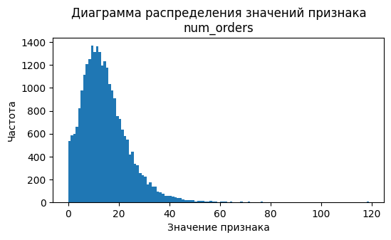

```python
plt.figure(figsize=(6, 3))
plt.title(label='Диаграмма распределения значений признака\nnum_orders')
plt.hist(data['num_orders'], bins=[n for n in range(120)])
plt.xlabel('Значение признака')
plt.ylabel('Частота')
plt.show()
```

`datetime` — дата и время регистрации значения количества заказов такси  
Значения определены для всех записей.  
Все значения уникальные.  
Первая отметка времени — 1 марта 2018 года 00:00.  
Последняя отметка времени — 31 августа 2018 года 23:50.

`num_orders` — количество заказов такси  
Значения определены для всех записей.  
Количество уникальных значений — 81.  
Значения определены с точностью до 1.  
Минимальное значение составляет 0, максимальное — 119.  
Медиана — 13, мода — 9 (её частота — 1373).  
Распределение значений унимодальное, смещено влево, с длинным "хвостом" справа.

## Предобработка данных

Проверим, являются ли все значения, обозначающие дату и время, уникальными и расположены ли они по возрастанию значений.

```python
data['datetime'].is_unique
```

```
True
```

```python
data['datetime'].is_monotonic_increasing
```

```
True
```

Посмотрим, на каких временных интервалах расположены идущие друг за другом временные метки в признаке `datetime`. Интервалы измерим в минутах.

```python
(
    (data['datetime'] - data['datetime'].shift()).drop([0]).dt.seconds / 60
    ).unique()
```

```
array([10.])
```

Все временные метки являются уникальными, расположенными по возрастанию значений на одинаковом интервале в 10 мин друг от друга. Следовательно, можно рассматривать набор данных как регулярный временной ряд.

### Индексация временными метками

Установим в качестве индекса значение даты и времени. Отсортируем набор данных по возрастанию даты и времени.

```python
data.set_index('datetime', inplace=True)
data.sort_index(inplace=True)
data.head()
```

| datetime | num_orders |
| --- | --- |
| 2018-03-01 00:00:00 | 9 |
| 2018-03-01 00:10:00 | 14 |
| 2018-03-01 00:20:00 | 28 |
| 2018-03-01 00:30:00 | 20 |
| 2018-03-01 00:40:00 | 32 |

```python
data.tail()
```

| datetime | num_orders |
| --- | --- |
| 2018-08-31 23:10:00 | 32 |
| 2018-08-31 23:20:00 | 24 |
| 2018-08-31 23:30:00 | 27 |
| 2018-08-31 23:40:00 | 39 |
| 2018-08-31 23:50:00 | 53 |

### Передискретизация

Выполним понижающую передискретизацию: рассчитаем количество вызовов такси за каждый час.

```python
data = data.resample('1H').sum()
data.head()
```

| datetime | num_orders |
| --- | --- |
| 2018-03-01 00:00:00 | 124 |
| 2018-03-01 01:00:00 | 85 |
| 2018-03-01 02:00:00 | 71 |
| 2018-03-01 03:00:00 | 66 |
| 2018-03-01 04:00:00 | 43 |

```python
data.tail()
```

| datetime | num_orders |
| --- | --- |
| 2018-08-31 19:00:00 | 136 |
| 2018-08-31 20:00:00 | 154 |
| 2018-08-31 21:00:00 | 159 |
| 2018-08-31 22:00:00 | 223 |
| 2018-08-31 23:00:00 | 205 |

### Обогащение данных

Добавим признак `num_orders_per_day`, содержащий значения количества заказов в день.

```python
data['num_orders_per_day'] = data['num_orders'].resample('1D').sum()
```

Выделим из значений признака `datetime` день недели — добавим признак `weekday`.

```python
data['weekday'] = data.index.weekday + 1
data['weekday'].sort_values().unique()
```

```
array([1, 2, 3, 4, 5, 6, 7])
```

Выделим из значений признака `datetime` число — добавим признак `day`.

```python
data['day'] = data.index.day
data['day'].sort_values().unique()
```

```
array([ 1,  2,  3,  4,  5,  6,  7,  8,  9, 10, 11, 12, 13, 14, 15, 16, 17,
       18, 19, 20, 21, 22, 23, 24, 25, 26, 27, 28, 29, 30, 31])
```

Добавим признак `is_weekend`, обозначающий факт того, что дни являются выходными.

```python
def is_weekend(row):

    if row['weekday'] > 5:
        return 1
    else:
        return 0
```

```python
data['is_weekend'] = data.apply(is_weekend, axis=1)
data['is_weekend'].unique()
```

```
array([0, 1])
```

Добавим признак `decade`, обозначающий номер декады месяца.

```python
def decade(row):

    if row['day'] <= 10:
        return 1
    elif row['day'] > 10 and row['day'] <= 20:
        return 2
    else:
        return 3
```

```python
data['decade'] = data.apply(decade, axis=1)
data['decade'].unique()
```

```
array([1, 2, 3])
```

## Описательный анализ данных

Предварительно зададим функцию, рассчитывающую описательные статистики.

```python
def descriptive_statistics(values, label):
    '''
    Описательная статистика переменной, измеряемой в количественной шкале.

    Принимает значения признака и название признака.
    Возвращает DataFrame с набором статистик.

    '''

    df = pd.DataFrame([
        values.count(),
        len(values.unique()),
        values.min(),
        values.median() - 1.5 * (values.quantile(q=.75) -
                                 values.quantile(q=.25)),
        values.quantile(q=.25).round(2),
        (values.mode()).to_list(),
        values.median().round(2),
        values.mean().round(2),
        values.quantile(q=.75).round(2),
        values.median() + 1.5 * (values.quantile(q=.75) -
                                 values.quantile(q=.25)),
        values.max(),
        values.max() - values.min(),
        values.quantile(q=.75) - values.quantile(q=.25)
    ],
        index=['кол-во значений', 'кол-во уникальных', 'мин.',
               '-1.5IQR', '25 %', 'мода', 'медиана',
               'среднее ариф.', '75 %', '+1.5IQR', 'макс.',
               'размах', 'межквартильный размах'],
        columns=[label])

    return df
```

### Количество заказов такси в час

```python
descriptive_statistics(data['num_orders'], 'Количество заказов такси в час')
```

|  | Количество заказов такси в час |
| --- | --- |
| кол-во значений | 4416 |
| кол-во уникальных | 251 |
| мин. | 0 |
| -1.5IQR | -1.5 |
| 25 % | 54.0 |
| мода | [73] |
| медиана | 78.0 |
| среднее ариф. | 84.42 |
| 75 % | 107.0 |
| +1.5IQR | 157.5 |
| макс. | 462 |
| размах | 462 |
| межквартильный размах | 53.0 |

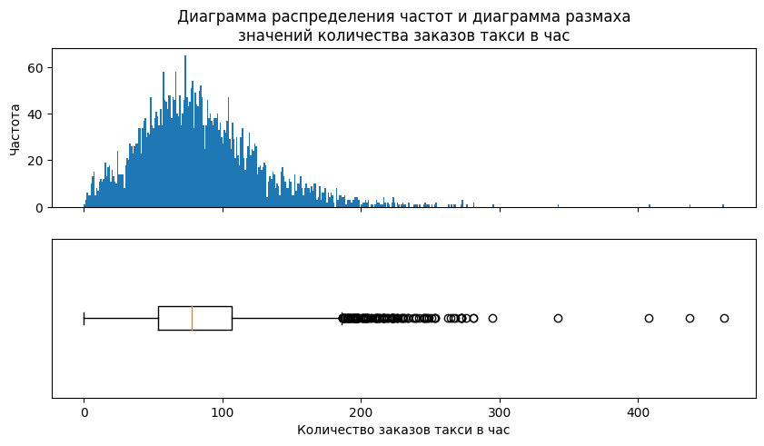

```python
fig, (ax1, ax2) = plt.subplots(2, 1, figsize=(10, 5))
ax1.set_title('Диаграмма распределения частот и диаграмма размаха' +
              '\nзначений количества заказов такси в час')
ax1.hist(data['num_orders'], bins=[n for n in range(463)])
ax1.tick_params(labelbottom=False)
ax1.set_ylabel('Частота')
ax2.boxplot(data['num_orders'], vert=False)
ax2.tick_params(left=False, labelleft=False)
ax2.set_xlabel('Количество заказов такси в час')
plt.show()
```

- Значения определены для каждого часа.
- Значения определены с точностью до 1.
- Для 4416 записей встречается 251 различное уникальное значение.
- Минимальное значение — 0, максимальное значение — 462.
- Мода — 73, медиана — 78.
- Распределение унимодальное, несимметричное. Смещено влево. С длинным "хвостом" справа.
- В половине всех наблюдений количество заказанных в каждый час такси колеблется от 54 до 107.
- Практически всегда принимается не более 158 заказов в час.

### Количество заказов такси в день

```python
descriptive_statistics(data['num_orders_per_day'],
                       'Количество заказов такси в день')
```

|  | Количество заказов такси в день |
| --- | --- |
| кол-во значений | 184 |
| кол-во уникальных | 174 |
| мин. | 1076.0 |
| -1.5IQR | 708.125 |
| 25 % | 1547.5 |
| мода | [1525.0, 1651.0, 1684.0, 1697.0, 1882.0, 1893.... |
| медиана | 1911.5 |
| среднее ариф. | 2026.15 |
| 75 % | 2349.75 |
| +1.5IQR | 3114.875 |
| макс. | 4090.0 |
| размах | 3014.0 |
| межквартильный размах | 802.25 |

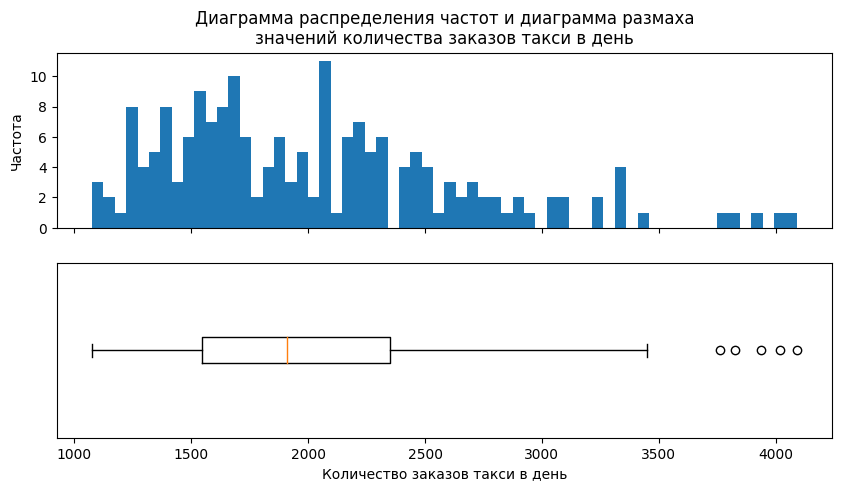

```python
fig, (ax1, ax2) = plt.subplots(2, 1, figsize=(10, 5))
ax1.set_title('Диаграмма распределения частот и диаграмма размаха' +
              '\nзначений количества заказов такси в день')
ax1.hist(data['num_orders_per_day'], bins=62)
ax1.tick_params(labelbottom=False)
ax1.set_ylabel('Частота')
ax2.boxplot(data['num_orders_per_day'].dropna(), vert=False)
ax2.tick_params(left=False, labelleft=False)
ax2.set_xlabel('Количество заказов такси в день')
plt.show()
```

- Значения определены для каждого дня.
- Значения определены с точностью до 1.
- Для 184 записей встречается 174 различных уникальных значений.
- Минимальное значение — 1076, максимальное значение — 4090.
- Медиана — 1911,5. Мода не информативна ввиду большого количества уникальных значений.
- Распределение дискретное.
- В половине всех наблюдений количество заказанных в каждый день такси колеблется от 1547 до 2350.
- Практически всегда принимается не более 3115 заказов в день.

### Дни недели

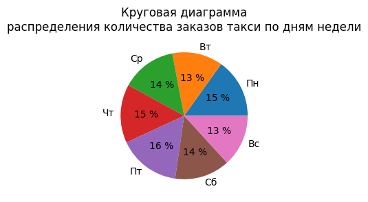

```python
labels = 'Пн', 'Вт', 'Ср', 'Чт', 'Пт', 'Сб', 'Вс'
plt.figure(figsize=(3, 3))
plt.pie(data.groupby('weekday')['num_orders'].sum(),
        labels=labels,
        autopct='%.0f %%')
plt.title('Круговая диаграмма' +
          '\nраспределения количества заказов такси по дням недели')
plt.show()
```

```python
pd.DataFrame(
    data.groupby('weekday')['num_orders'].sum().reset_index(
        drop=True)).T.rename(
            columns={0:'Пн', 1:'Вт', 2:'Ср', 3:'Чт', 4:'Пт', 5:'Сб', 6:'Вс'},
            index={'num_orders': 'Кол-во заказов такси'})
```

|  | Пн | Вт | Ср | Чт | Пт | Сб | Вс |
| --- | --- | --- | --- | --- | --- | --- | --- |
| Кол-во заказов такси | 56314 | 48055 | 52263 | 55508 | 59059 | 52321 | 49291 |

- Значения количества заказов такси распределено по дням недели неравномерно.
- Меньше всего — по 13 % от всех заказов — было совершено во вторник и в воскресенье (около 48–49 тыс.).
- По 14 % от всех заказов было совершено в среду и в субботу (около 52 тыс.).
- По 15 % от всех заказов совершено в понедельник и в четверг (около 56 тыс.).
- Больше всего — 16 % всех заказов — выполнялось в пятницу (около 59 тыс.).

### Выходные дни

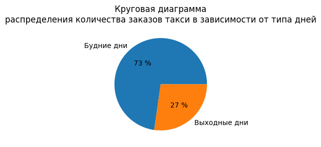

```python
labels = 'Будние дни', 'Выходные дни'
plt.figure(figsize=(3, 3))
plt.pie(data.groupby('is_weekend')['num_orders'].sum(),
        labels=labels,
        autopct='%.0f %%')
plt.title('Круговая диаграмма' +
          '\nраспределения количества заказов такси в зависимости от типа дней')
plt.show()
```

```python
pd.DataFrame(data.groupby('is_weekend')['num_orders'].sum().reset_index(
    drop=True)).T.rename(
            columns={0:'Будние дни', 1:'Выходные дни'},
            index={'num_orders': 'Кол-во заказов такси'})
```

|  | Будние дни | Выходные дни |
| --- | --- | --- |
| Кол-во заказов такси | 271199 | 101612 |

- Отношение количества заказов в будние дни к количеству заказов в выходные составляет почти 2,7 : 1.
- Чуть больше четверти всех заказов такси (27 %) приходится на выходные дни — субботу и воскресенье.

### Декады

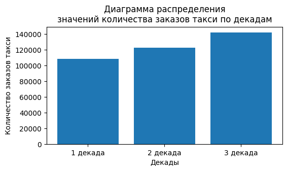

```python
plt.figure(figsize=(6, 3))
plt.title('Диаграмма распределения' +
          '\nзначений количества заказов такси по декадам')
plt.bar(['1 декада', '2 декада', '3 декада'],
        height=data.groupby('decade')['num_orders'].sum())
plt.xlabel('Декады')
plt.ylabel('Количество заказов такси')
plt.show()
```

```python
pd.DataFrame(data.groupby('decade')['num_orders'].sum().reset_index(
    drop=True)).T.rename(
            columns={0:'1 декада', 1:'2 декада', 2:'3 декада'},
            index={'num_orders': 'Кол-во заказов такси'})
```

|  | 1 декада | 2 декада | 3 декада |
| --- | --- | --- | --- |
| Кол-во заказов такси | 108283 | 122579 | 141949 |

- Распределение заказов такси по декадам месяцев неравномерно.
- Меньше всего заказов поступает в первые декады месяца — около 108 тыс. (почти 29 % всех заказов).
- Во вторые декады поступило около 123 тыс. заказов (около 33 % всех заказов).
- Больше всего совершено заказов в третьи декады месяца — около 142 тыс. (почти 38 % всех заказов).

### Скользящие оконные функции

Для описания ежедневного непрерывного изменения количества заказов такси в качестве скользящего окна выберем временной интервал в 24 часа. В качестве обрабатываемых данных возьмём значения ежечасного изменения количества заказов такси.

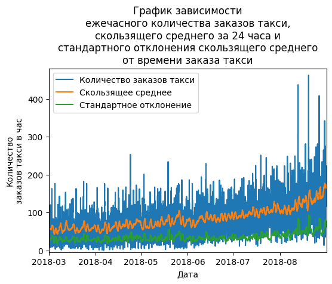

```python
plt.figure(figsize=(6, 4))
plt.title('График зависимости' +
          '\nежечасного количества заказов такси,' +
          '\nскользящего среднего за 24 часа и' +
          '\nстандартного отклонения скользящего среднего' +
          '\nот времени заказа такси')
plt.plot(data['num_orders'])
plt.plot(data['num_orders'].rolling(24).mean())
plt.plot(data['num_orders'].rolling(24).std())
plt.xlabel('Дата')
plt.ylabel('Количество\nзаказов такси в час')
plt.xlim(data.index.min(), data.index.max())
plt.ylim(-5, 480)
plt.legend(['Количество заказов такси',
            'Скользящее среднее',
            'Стандартное отклонение'])
plt.show()
```

- Значение количества ежечасных заказов изменяется неравномерно. В течение всего исследуемого периода наблюдается большое число выбросов, особенно отчётливо они наблюдаются в конце исследуемого периода.
- Количество заказов в день растёт в течение наблюдаемого периода.
- Есть периоды, в которые наблюдается большой разброс значений в течение наблюдаемых 24 часов, что отражается наличием выбивающихся пиков на графике стандартного отклонения.
- К концу наблюдаемого периода увеличивается стандартное отклонение, что является следствием наличия значительных выбросов.

Для описания еженедельного непрерывного изменения количества заказов такси в качестве скользящего окна выберем временной интервал в 7 дней. В качестве обрабатываемых данных возьмём значения ежедневного изменения количества заказов такси.

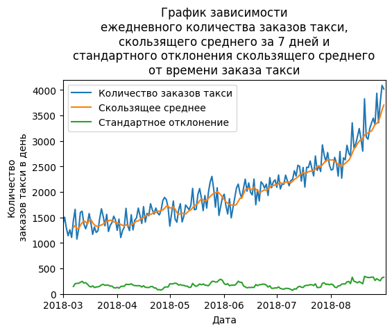

```python
plt.figure(figsize=(6, 4))
plt.title('График зависимости' +
          '\nежедневного количества заказов такси,' +
          '\nскользящего среднего за 7 дней и' +
          '\nстандартного отклонения скользящего среднего' +
          '\nот времени заказа такси')
plt.plot(data['num_orders_per_day'].dropna())
plt.plot(data['num_orders_per_day'].dropna().rolling(7).mean())
plt.plot(data['num_orders_per_day'].dropna().rolling(7).std())
plt.xlabel('Дата')
plt.ylabel('Количество\nзаказов такси в день')
plt.xlim(data.index.min(), data.index.max())
plt.ylim(0, 4200)
plt.legend(['Количество заказов такси',
            'Скользящее среднее',
            'Стандартное отклонение'])
plt.show()
```

- Значение количества ежедневных заказов изменяется также неравномерно. На данном графике ещё более отчётливо наблюдается рост заказов такси к концу исследуемого периода.
- В течение каждого месяца на графике скользящего среднего наблюдается провал в первой трети месяца, за которым, во вторую треть, следует рост значений и достижение максимального значения в последней трети месяца, за которым следует спад значений в первой трети следующего месяца. Поэтому логично выделение декад в отдельный признак, поскольку наблюдается цикличность изменения значений именно по декадам.
- Значение стандартного отклонения находится на одном уровне, что свидетельствует об одинаковой степени разброса относительно своего среднего значений, взятых для временного интервала в одну неделю.

### Тренды и сезонные составляющие

Разложим временные ряды, семплированные по часу и по дню, на составляющие: трендовую и сезонную.

```python
decomposed_hour = seasonal_decompose(data['num_orders'])
decomposed_day = seasonal_decompose(data['num_orders_per_day'].dropna())
```

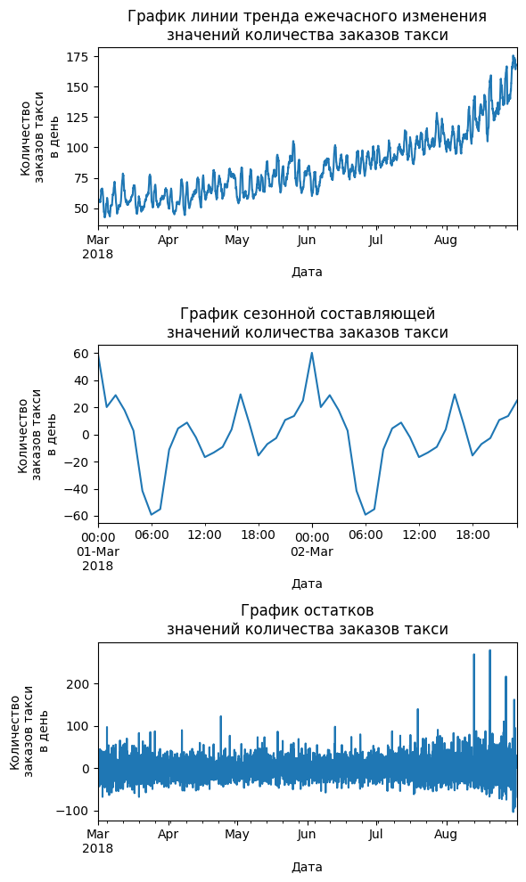

```python
plt.figure(figsize=(6, 10))
plt.subplot(311)
plt.title('График линии тренда ежечасного изменения' +
          '\nзначений количества заказов такси')
decomposed_hour.trend.plot()
plt.xlabel('Дата')
plt.ylabel('Количество\nзаказов такси\nв день')
plt.subplot(312)
plt.title('График сезонной составляющей\nзначений количества заказов такси')
decomposed_hour.seasonal[:'2018-03-02'].plot()
plt.xlabel('Дата')
plt.ylabel('Количество\nзаказов такси\nв день')
plt.subplot(313)
plt.title('График остатков\nзначений количества заказов такси')
decomposed_hour.resid.plot()
plt.xlabel('Дата')
plt.ylabel('Количество\nзаказов такси\nв день')
plt.tight_layout()
```

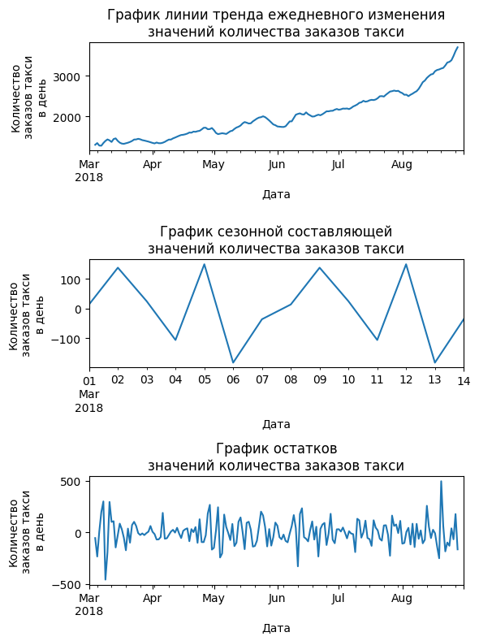

```python
plt.figure(figsize=(6, 8))
plt.subplot(311)
plt.title('График линии тренда ежедневного изменения' +
          '\nзначений количества заказов такси')
decomposed_day.trend.plot()
plt.xlabel('Дата')
plt.ylabel('Количество\nзаказов такси\nв день')
plt.subplot(312)
plt.title('График сезонной составляющей\nзначений количества заказов такси')
decomposed_day.seasonal[:'2018-03-14'].plot()
plt.xlabel('Дата')
plt.ylabel('Количество\nзаказов такси\nв день')
plt.subplot(313)
plt.title('График остатков\nзначений количества заказов такси')
decomposed_day.resid.plot()
plt.xlabel('Дата')
plt.ylabel('Количество\nзаказов такси\nв день')
plt.tight_layout()
```

- Также наблюдается тренд к увеличению количества заказов такси в день. Причём на графике тренда также заметны циклические изменения количества заказов в течение месяца — в первую, вторую и третью декады.
- Цикличность изменения количества заказов такси наблюдается через каждые 7 дней.
- Минимальное значение заказов совершают во вторник.
- Со вторника по пятницу наблюдается рост количества заказов.
- С пятницы по воскресенье наблюдается снижение спроса на такси.
- Взрывной рост количества заказов такси приходится на понедельник, за которым следует резкий спад.

## Построение моделей

### Подготовка данных для обучения

#### Удаление лишних признаков

Для целей построения модели, предсказывающей количество заказов такси на следующий час, признак `num_orders_per_day` не представляет ценности, поскольку агрегирует значения нескольких предсказываемых наблюдений и, таким образом, содержит сведения из будущего.

Удалим признак `num_orders_per_day` из набора данных.

```python
data.drop(['num_orders_per_day'], axis=1, inplace=True)
data.columns.sort_values().tolist()
```

```
['day', 'decade', 'is_weekend', 'num_orders', 'weekday']
```

#### Генерирование признаков

Выполним почасовые сдвиги данных вдоль временной оси вперёд до достижения значения сдвига в 24 часа. Создадим признаки `lag_N`, где N — количество часов, на которые выполняется сдвиг.

```python
N_HOURS = 24

for lag in range(1, N_HOURS+1):
    data['lag_{}'.format(lag)] = data['num_orders'].shift(lag)
```

Рассчитаем значение скользящего среднего для 6, 12, 24 и 48 часов. Создадим признаки `rolling_mean_N`, где N — временной интервал скользящего окна.

```python
N_HOURS = [6, 12, 24, 48]

for window in N_HOURS:
    data['rolling_mean_{}'.format(window)] = \
    data['num_orders'].shift().rolling(window).mean()
```

Рассчитаем разности временного ряда. Создадим признак `diff`. Поскольку цикличность почасовых значений наблюдается с интервалом 24 часа, поэтому, чтобы не подглянуть в будущее, для расчёта разности временого ряда будем использовать значения того же часа и предыдущего часа, но днём ранее.

```python
data['diff'] = data['num_orders'].shift(24) - data['num_orders'].shift(25)
```

```python
data.columns
```

```
Index(['num_orders', 'weekday', 'day', 'is_weekend', 'decade', 'lag_1',
       'lag_2', 'lag_3', 'lag_4', 'lag_5', 'lag_6', 'lag_7', 'lag_8', 'lag_9',
       'lag_10', 'lag_11', 'lag_12', 'lag_13', 'lag_14', 'lag_15', 'lag_16',
       'lag_17', 'lag_18', 'lag_19', 'lag_20', 'lag_21', 'lag_22', 'lag_23',
       'lag_24', 'rolling_mean_6', 'rolling_mean_12', 'rolling_mean_24',
       'rolling_mean_48', 'diff'],
      dtype='object')
```

Удалим записи, содержащие пропущенные значения в образованных признаках.

```python
data.dropna(inplace=True)
data.isna().sum().sum()
```

```
0
```

#### Кодирование признаков

Для учёта цикличности в следовании дней недели используем подход с использованием тригонометрической окружности.

```python
data['weekday_sin'] = np.sin(2 * np.pi * data['weekday'] / 7)
data['weekday_cos'] = np.cos(2 * np.pi * data['weekday'] / 7)
```

```python
data.columns.sort_values()
```

```
Index(['day', 'decade', 'diff', 'is_weekend', 'lag_1', 'lag_10', 'lag_11',
       'lag_12', 'lag_13', 'lag_14', 'lag_15', 'lag_16', 'lag_17', 'lag_18',
       'lag_19', 'lag_2', 'lag_20', 'lag_21', 'lag_22', 'lag_23', 'lag_24',
       'lag_3', 'lag_4', 'lag_5', 'lag_6', 'lag_7', 'lag_8', 'lag_9',
       'num_orders', 'rolling_mean_12', 'rolling_mean_24', 'rolling_mean_48',
       'rolling_mean_6', 'weekday', 'weekday_cos', 'weekday_sin'],
      dtype='object')
```

#### Разделение данных на выборки

Выделим из данных целевой признак `num_orders`.

```python
features = data.drop(['num_orders'], axis=1)
target = data['num_orders']
```

Поскольку отдельной тестовой выборки нет, разделим данные на тренировочную и тестовую выборки в отношении 9 : 1.

```python
features_train, features_test, target_train, target_test = train_test_split(
    features, target, test_size=0.1, random_state=RANDOM_STATE, shuffle=False)
```

Посмотрим, какие выборки получились после разделения.

```python
features_train.shape
```

```
(3931, 35)
```

```python
features_test.shape
```

```
(437, 35)
```

Убедимся в корретности деления. Проверим первые и последние индексы сформированных выборок.

```python
features_train.index.min(), features_train.index.max()
```

```
(Timestamp('2018-03-03 00:00:00', freq='H'),
 Timestamp('2018-08-13 18:00:00', freq='H'))
```

```python
features_test.index.min(), features_test.index.max()
```

```
(Timestamp('2018-08-13 19:00:00', freq='H'),
 Timestamp('2018-08-31 23:00:00', freq='H'))
```

#### Кодирование и масштабирование значений признаков

Выделим в наборе данных признаки категориального (в том числе бинарного) и количественного типа. Удалим из перечня признаков количественного типа признаки, не требующе масштабирования.

```python
categorical_columns = ['weekday', 'decade', 'day']
binary_columns = ['is_weekend']
numerical_columns = features_train.drop(categorical_columns+binary_columns,
                                        axis=1).columns.tolist()
numerical_columns.remove('weekday_sin')
numerical_columns.remove('weekday_cos')
```

Укажем, для каких признаков какое преобразование требуется выполнить: масштабирование или прямое кодирование.

```python
transformer = make_column_transformer(
    (StandardScaler(), numerical_columns),
    (OneHotEncoder(drop='first', handle_unknown='ignore'), categorical_columns)
)
```

### Обучение моделей

Поскольку признак `num_orders` — количественный (абсолютный), следовательно, необходимо решить задачу регрессии.

Зафиксируем псевдослучайность для алгоритмов обучения.

Оценку качества обученных моделей будем проводить, рассчитывая значение среднеквадратичной ошибки (RMSE). Обученная модель будет считаться выполняющей качественный прогноз, если значение среднеквадратичной ошибки не будет превышать 48.

Для того чтобы получить максимально высокое качество предсказания, нужно перебрать в алгоритмах обучения разные значения гиперпараметров. Наилучшими гиперпараметрами для моделей признаем те, при которых получится минимальное значение RMSE, оценённое при проведении кросс-валидации.

#### Валидация

Подбор параметров моделей и оценку качества обучаемых моделей будем производить кросс-валидацией. Подвыборки будем формировать схожими по размеру тестовой выборке. Таким образом, количество формируемых подвыборок для обучения одной модели равно 9.

```python
N_SPLITS = 9
```

Предварительно зададим функцию, рассчитывающую метрики качества моделей в результате проведения кросс-валидации. Учтём, что работаем с временным рядом, и поэтому формировать обучающие выборки будем из данных, расположенных на временной оси раньше валидационных.

```python
tscv = TimeSeriesSplit(n_splits=N_SPLITS)
```

Зададим функцию для расчёта среднеквадратичной ошибки (RMSE) при проведении кросс-валидации.

```python
def cv_score(model, X=features_train, y=target_train):
    '''
    Функция расчёта метрики качества (RMSE) модели,
    полученной в результате кросс-валидации.

    Принимает алгоритм с заданными гиперпараметрами
    (опционально - тренировочные данные).
    Возвращает среднее значение среднеквадратичной ошибки (RMSE).
    '''

    return abs(cross_val_score(model, X=X, y=y,
                               cv=tscv, n_jobs=-1, error_score='raise',
                               scoring='neg_root_mean_squared_error').mean())
```

#### Простая модель

```python
class DummyRegressor(BaseEstimator, RegressorMixin):
    '''
    Простой фиктивный регрессор, который возвращает
    значения с запаздыванием, определяемые параметром стратегии.

    strategy: тип integer, по умолчанию 1.
    Количество лагов, используемых для прогнозирования.
    '''

    def __init__(self, strategy=1):

        self.strategy = strategy

    def fit(self, X, y=None):

        return self

    def predict(self, X):

        return X[f'lag_{self.strategy}']
```

```python
%%time

model_dummy = DummyRegressor()

model_dummy_score = cv_score(model_dummy)

print('Простая модель, предсказывающая значение предыдущего часа')
print('\nRMSE =', round(model_dummy_score, 1), '\n')
```

```
Простая модель, предсказывающая значение предыдущего часа

RMSE = 36.5

CPU times: user 87.5 ms, sys: 64.5 ms, total: 152 ms
Wall time: 2.06 s
```

```python
%%time

model_dummy = DummyRegressor(strategy=24)

model_dummy_score = cv_score(model_dummy)

print('Простая модель, предсказывающая значение этого же часа предыдущего дня')
print('\nRMSE =', round(model_dummy_score, 1), '\n')
```

```
Простая модель, предсказывающая значение этого же часа предыдущего дня

RMSE = 32.0

CPU times: user 33.9 ms, sys: 7 ms, total: 40.9 ms
Wall time: 86.6 ms
```

#### Линейная регрессия

```python
%%time

model_lr = LinearRegression(n_jobs=-1)

pipeliner = make_pipeline(transformer, model_lr)

model_lr_score = cv_score(pipeliner)

print('Модель линейной регрессии')
print('\nRMSE =', round(model_lr_score, 1), '\n')
```

```
Модель линейной регрессии

RMSE = 27.5

CPU times: user 61.4 ms, sys: 6.95 ms, total: 68.3 ms
Wall time: 821 ms
```

#### Стохастический градиентный спуск

```python
%%time

model_sgdr = SGDRegressor(random_state=RANDOM_STATE)
pipeliner = make_pipeline(transformer, model_sgdr)

parameters = {'sgdregressor__alpha': [10**n for n in range(1, -7, -1)],
              'sgdregressor__tol': [10**n for n in range(1, -6, -1)],
              'sgdregressor__eta0': [10**n for n in range(1, -4, -1)]}

sgdr = RandomizedSearchCV(pipeliner, param_distributions=parameters, cv=tscv,
                          n_iter=100, scoring='neg_root_mean_squared_error',
                          random_state=RANDOM_STATE, n_jobs=-1,
                          error_score='raise')

sgdr.fit(features_train, target_train)

print('Модель стохастического градиентного спуска')
print('\nRMSE =', round(abs(sgdr.best_score_), 1))
print('\nПараметры наилучшей модели:',
      pd.DataFrame(sgdr.best_params_, index = ['']).T, '\n')
```

```
Модель стохастического градиентного спуска

RMSE = 26.7

Параметры наилучшей модели:
sgdregressor__tol    0.10
sgdregressor__eta0   0.01
sgdregressor__alpha  0.10

CPU times: user 4.06 s, sys: 408 ms, total: 4.47 s
Wall time: 1min 22s
```

#### Гребневая регрессия

```python
%%time

model_ridge = Ridge(random_state=RANDOM_STATE)
pipeliner = make_pipeline(transformer, model_ridge)

parameters = {'ridge__alpha': [10**n for n in range(2, -2, -1)],
              'ridge__tol': [10**n for n in range(1, -6, -1)],
              'ridge__max_iter': [None]+[10**n for n in range(1, 4, 1)]}

ridge = RandomizedSearchCV(pipeliner, param_distributions=parameters, cv=tscv,
                           n_iter=100, scoring='neg_root_mean_squared_error',
                           random_state=RANDOM_STATE, n_jobs=-1,
                           error_score='raise')

ridge.fit(features_train, target_train)

print('Модель гребневой регрессии')
print('\nRMSE =', round(abs(ridge.best_score_), 1))
print('\nПараметры наилучшей модели:',
      pd.DataFrame(ridge.best_params_, index = ['']).T, '\n')
```

```
Модель гребневой регрессии

RMSE = 26.5

Параметры наилучшей модели:
ridge__tol        0.1
ridge__max_iter  None
ridge__alpha      100

CPU times: user 2.12 s, sys: 176 ms, total: 2.3 s
Wall time: 17 s
```

#### Регрессия LASSO

```python
%%time

model_lasso = Lasso(random_state=RANDOM_STATE)
pipeliner = make_pipeline(transformer, model_lasso)

parameters = {'lasso__alpha': [10**n for n in range(3, -4, -1)],
              'lasso__tol': [10**n for n in range(1, -6, -1)],
              'lasso__max_iter': [10**n for n in range(1, 6, 1)]}

lasso = RandomizedSearchCV(pipeliner, param_distributions=parameters, cv=tscv,
                           n_iter=100, scoring='neg_root_mean_squared_error',
                           random_state=RANDOM_STATE, n_jobs=-1,
                           error_score='raise')

lasso.fit(features_train, target_train)

print('Модель регрессии Lasso')
print('\nRMSE =', round(abs(lasso.best_score_), 1))
print('\nПараметры наилучшей модели:',
      pd.DataFrame(lasso.best_params_, index = ['']).T, '\n')
```

```
Модель регрессии Lasso

RMSE = 26.6

Параметры наилучшей модели:
lasso__tol         0.01
lasso__max_iter  100.00
lasso__alpha       0.10

CPU times: user 2.38 s, sys: 213 ms, total: 2.59 s
Wall time: 33.7 s
```

#### Дерево решений

```python
%%time

model_dtr = DecisionTreeRegressor(random_state=RANDOM_STATE)
pipeliner = make_pipeline(transformer, model_dtr)

parameters = {
    'decisiontreeregressor__max_depth': [None]+[n for n in range(1, 31, 1)],
    'decisiontreeregressor__min_samples_leaf': [n for n in range(1, 31, 1)],
    'decisiontreeregressor__min_samples_split': [n for n in range(2, 11, 1)]
    }

dtr = RandomizedSearchCV(pipeliner, param_distributions=parameters, cv=tscv,
                         n_iter=200, scoring='neg_root_mean_squared_error',
                         random_state=RANDOM_STATE, n_jobs=-1,
                         error_score='raise')

dtr.fit(features_train, target_train)

print('Модель решающего дерева')
print('\nRMSE =', round(abs(dtr.best_score_), 1))
print('\nПараметры наилучшей модели:',
      pd.DataFrame(dtr.best_params_, index = ['']).T, '\n')
```

```
Модель решающего дерева

RMSE = 27.8

Параметры наилучшей модели:
decisiontreeregressor__min_samples_split   4
decisiontreeregressor__min_samples_leaf   18
decisiontreeregressor__max_depth           7

CPU times: user 6.51 s, sys: 627 ms, total: 7.13 s
Wall time: 1min 29s
```

#### Случайный лес

```python
%%time

model_rfr = RandomForestRegressor(random_state=RANDOM_STATE, n_jobs=-1)
pipeliner = make_pipeline(transformer, model_rfr)

parameters = {
    'randomforestregressor__n_estimators': [n for n in range(10, 310, 10)],
    'randomforestregressor__max_depth': [None]+[n for n in range(1, 11, 1)]
    }

rfr = RandomizedSearchCV(pipeliner, param_distributions=parameters, cv=tscv,
                         n_iter=30, scoring='neg_root_mean_squared_error',
                         random_state=RANDOM_STATE, n_jobs=-1,
                         error_score='raise')

rfr.fit(features_train, target_train)

print('Модель случайного леса')
print('\nRMSE =', round(abs(rfr.best_score_), 1))
print('\nПараметры наилучшей модели:',
      pd.DataFrame(rfr.best_params_, index = ['']).T, '\n')
```

```
Модель случайного леса

RMSE = 24.8

Параметры наилучшей модели:
randomforestregressor__n_estimators   190
randomforestregressor__max_depth     None

CPU times: user 36.2 s, sys: 1.23 s, total: 37.5 s
Wall time: 12min 28s
```

#### Градиентный бустинг

##### Базовая модель градиентного бустинга

```python
%%time

model_gbr = GradientBoostingRegressor()
pipeliner = make_pipeline(transformer, model_gbr)

parameters = {
    'gradientboostingregressor__n_estimators':
     [10, 20, 50, 100, 200, 500, 1000],
    'gradientboostingregressor__learning_rate':
     [0.005, 0.01, 0.05]+[0.1*n for n in range(1, 2)]}

gbr = RandomizedSearchCV(pipeliner, param_distributions=parameters, cv=tscv,
                         n_iter=20, scoring='neg_root_mean_squared_error',
                         random_state=RANDOM_STATE, n_jobs=-1,
                         error_score='raise')

gbr.fit(features_train, target_train)

print('Модель градиентного бустинга на основе алгоритма scikit-learn')
print('\nRMSE =', round(abs(gbr.best_score_), 1))
print('\nПараметры наилучшей модели:',
      pd.DataFrame(gbr.best_params_, index = ['']).T, '\n')
```

```
Модель градиентного бустинга на основе алгоритма scikit-learn

RMSE = 25.3

Параметры наилучшей модели:
gradientboostingregressor__n_estimators   200.00
gradientboostingregressor__learning_rate    0.05

CPU times: user 11.6 s, sys: 1.12 s, total: 12.7 s
Wall time: 8min 24s
```

##### LightGBM

```python
%%time

model_lightgbm = LGBMRegressor()
pipeliner = make_pipeline(transformer, model_lightgbm)

parameters = {
    'lgbmregressor__n_estimators': [10, 20, 50, 100, 200, 500, 1000],
    'lgbmregressor__learning_rate':
     [0.005, 0.01, 0.05]+[0.1*n for n in range(1, 2)]}

lightgbm = RandomizedSearchCV(pipeliner, param_distributions=parameters,
                              cv=tscv, n_iter=20,
                              scoring='neg_root_mean_squared_error',
                              random_state=RANDOM_STATE, n_jobs=-1,
                              error_score='raise')

lightgbm.fit(features_train, target_train)

print('Модель градиентного бустинга на основе алгоритма LightGBM')
print('\nRMSE =', round(abs(lightgbm.best_score_), 1))
print('\nПараметры наилучшей модели:',
      pd.DataFrame(lightgbm.best_params_, index = ['']).T, '\n')
```

```
[LightGBM] [Warning] Auto-choosing col-wise multi-threading, the overhead of testing was 0.001427 seconds.
You can set `force_col_wise=true` to remove the overhead.
[LightGBM] [Info] Total Bins 5837
[LightGBM] [Info] Number of data points in the train set: 3931, number of used features: 67
[LightGBM] [Info] Start training from score 78.589163
Модель градиентного бустинга на основе алгоритма LightGBM

RMSE = 24.7

Параметры наилучшей модели:
lgbmregressor__n_estimators   1000.000
lgbmregressor__learning_rate     0.005

CPU times: user 5.66 s, sys: 342 ms, total: 6 s
Wall time: 1min 49s
```

##### XGBoost

```python
%%time

model_xgboost = XGBRegressor()
pipeliner = make_pipeline(transformer, model_xgboost)

parameters = {
    'xgbregressor__n_estimators': [10, 20, 50, 100, 200, 500, 1000],
    'xgbregressor__learning_rate':
     [0.005, 0.01, 0.05]+[0.1*n for n in range(1, 2)]}

xgboost = RandomizedSearchCV(pipeliner, param_distributions=parameters, cv=tscv,
                             n_iter=10, scoring='neg_root_mean_squared_error',
                             random_state=RANDOM_STATE, n_jobs=-1,
                             error_score='raise')

xgboost.fit(features_train, target_train)

print('Модель градиентного бустинга на основе алгоритма XGBoost')
print('\nRMSE =', round(abs(xgboost.best_score_), 1))
print('\nПараметры наилучшей модели:',
      pd.DataFrame(xgboost.best_params_, index = ['']).T, '\n')
```

```
Модель градиентного бустинга на основе алгоритма XGBoost

RMSE = 25.1

Параметры наилучшей модели:
xgbregressor__n_estimators   500.00
xgbregressor__learning_rate    0.05

CPU times: user 16.9 s, sys: 454 ms, total: 17.3 s
Wall time: 3min 11s
```

##### CatBoost

```python
%%time

model_catboost = CatBoostRegressor(cat_features=categorical_columns,
                                   verbose=False)

parameters = {'n_estimators': [10, 20, 50, 100, 200, 500, 1000],
              'learning_rate': [0.005, 0.01, 0.05]+[0.1*n for n in range(1, 2)]}

catboost = RandomizedSearchCV(model_catboost, param_distributions=parameters,
                              cv=tscv, n_iter=10,
                              scoring='neg_root_mean_squared_error',
                              random_state=RANDOM_STATE, n_jobs=-1,
                              error_score='raise')

catboost.fit(features_train, target_train)

print('Модель градиентного бустинга на основе алгоритма CatBoost')
print('\nRMSE =', round(abs(catboost.best_score_), 1))
print('\nПараметры наилучшей модели:',
      pd.DataFrame(catboost.best_params_, index = ['']).T, '\n')
```

```
Модель градиентного бустинга на основе алгоритма CatBoost

RMSE = 23.8

Параметры наилучшей модели:
n_estimators   1000.00
learning_rate     0.05

CPU times: user 21.6 s, sys: 1.1 s, total: 22.7 s
Wall time: 3min 10s
```

### Оценка модели

```python
model = CatBoostRegressor(cat_features=categorical_columns,
                          n_estimators=1000,
                          learning_rate=0.05,
                          verbose=False)

model.fit(features_train, target_train)
predictions = model.predict(features_test)

print('Модель градиентного бустинга на основе алгоритма CatBoost')
print('\nЗначение среднеквадратичной ошибки на тестовой выборке')
print('RMSE =', round(abs(mean_squared_error(target_test, predictions,
                                             squared=False)), 1))
```

```
Модель градиентного бустинга на основе алгоритма CatBoost

Значение среднеквадратичной ошибки на тестовой выборке
RMSE = 40.9
```

```python
result = pd.DataFrame(predictions,
                      index=target_test.index,
                      columns=['predictions']).join(target_test)
```

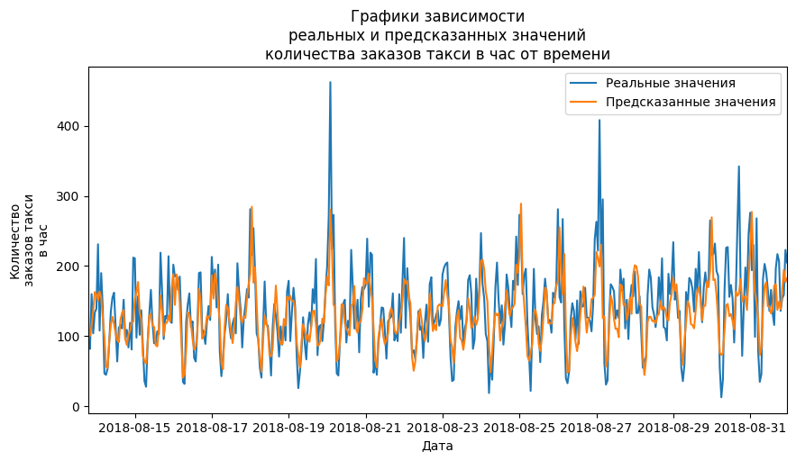

```python
plt.figure(figsize=(10, 5))
plt.title('Графики зависимости\nреальных и предсказанных значений' +
          '\nколичества заказов такси в час от времени')
plt.plot(result['num_orders'])
plt.plot(result['predictions'])
plt.xlabel('Дата')
plt.ylabel('Количество\nзаказов такси\nв час')
plt.xlim(result.index.min(), result.index.max())
plt.legend(['Реальные значения', 'Предсказанные значения'])
plt.show()
```

- Изменения, происходящие на графике зависимости предсказанных значений количества заказов такси в час от времени, повторяют изменения, происходящие на графике реальных значений. Следовательно, модель была подобрана корректно.

## Общий вывод

1. Для целей предсказания количества заказов такси были обучены линейные модели:
- линейная регрессия,
- стохастический градиентный спуск,
- гребневая регрессия,
- регрессия LASSO,

а также модели, основанные на использовании деревьев решений:

- дерево решений,
- случайный лес,
- градиентный бустинг sklearn,
- градиентный бустинг LightGBM,
- градиентный бустинг XGBoost,
- градиентный бустинг CatBoost.
2. Для сравнения алгоритмов были обучены простые модели, предсказывающие значение количества заказов предыдущего часа и предсказывающие значение этого же часа, но предыдущего дня.
3. Для каждого алгоритма было обучено несколько моделей с различными гиперпараметрами.
4. Критерием отбора моделей для дальнейшего исследования было значение среднеквадратичной ошибки (RMSE) предсказания количества заказов такси, полученной в результате проведения кросс-валидации. Пороговое значение RMSE установлено на уровне 48.
5. Все модели обеспечивают высокое качество предсказания. Значения RMSE для всех обученных моделей не превышает 48.

| Модель и её параметры | RMSE |
| --- | --- |
| **Простая модель** |  |
| – предсказывает значение предыдущего часа | 36,5 |
| – предсказывает значение этого же часа предыдущего дня | 32,0 |
| **Линейная регрессия** | 27,5 |
| **Стохастический градиентный спуск** | 26,7 |
| – альфа: 0,1, начальная скорость обучения: 0,01, порог остановки обучения: 0,1 |  |
| **Гребневая регрессия** | 26,5 |
| – альфа: 100, максимальное число итераций: None, порог остановки обучения: 0,1 |  |
| **Регрессия LASSO** | 26,6 |
| – альфа: 0,1, максимальное число итераций: 100, порог остановки обучения: 0,01 |  |
| **Дерево решений** | 27,8 |
| – глубина дерева: 7, минимальное число листьев: 18, минимальное количество выборок: 4 |  |
| **Случайный лес** | 24,8 |
| – число деревьев: 190, глубина дерева: None |  |
| **Градиентный бустинг sklearn** | 25,3 |
| – число итераций: 200, скорость обучения: 0,05 |  |
| **LightGBM** | 24,7 |
| – число итераций: 1000, скорость обучения: 0,005 |  |
| **XGBoost** | 25,1 |
| – число итераций: 500, скорость обучения: 0,05 |  |
| **CatBoost** | 23,8 |
| – число итераций: 1000, скорость обучения: 0,05 |  |

6. Наилучшие показатели качества демонстрирует модель градиентного бустинга на основе алгоритма CatBoost с числом итераций — 1000 и скоростью обучения — 0,05.